# Wine Quality Exploration by Kedarnath Vilankar

```
## [1] 1599   12
```

```
##  fixed.acidity   volatile.acidity  citric.acid    residual.sugar
##  Min.   : 4.60   Min.   :0.1200   Min.   :0.000   Min.   : 0.900
##  1st Qu.: 7.10   1st Qu.:0.3900   1st Qu.:0.090   1st Qu.: 1.900
##  Median : 7.90   Median :0.5200   Median :0.260   Median : 2.200
##  Mean   : 8.32   Mean   :0.5278   Mean   :0.271   Mean   : 2.539
##  3rd Qu.: 9.20   3rd Qu.:0.6400   3rd Qu.:0.420   3rd Qu.: 2.600
##  Max.   :15.90   Max.   :1.5800   Max.   :1.000   Max.   :15.500
##    chlorides       free.sulfur.dioxide total.sulfur.dioxide
##  Min.   :0.01200   Min.   : 1.00       Min.   :  6.00
##  1st Qu.:0.07000   1st Qu.: 7.00       1st Qu.: 22.00
##  Median :0.07900   Median :14.00       Median : 38.00
##  Mean   :0.08747   Mean   :15.87       Mean   : 46.47
##  3rd Qu.:0.09000   3rd Qu.:21.00       3rd Qu.: 62.00
##  Max.   :0.61100   Max.   :72.00       Max.   :289.00
##     density             pH          sulphates         alcohol
##  Min.   :0.9901   Min.   :2.740   Min.   :0.3300   Min.   : 8.40
##  1st Qu.:0.9956   1st Qu.:3.210   1st Qu.:0.5500   1st Qu.: 9.50
##  Median :0.9968   Median :3.310   Median :0.6200   Median :10.20
##  Mean   :0.9967   Mean   :3.311   Mean   :0.6581   Mean   :10.42
##  3rd Qu.:0.9978   3rd Qu.:3.400   3rd Qu.:0.7300   3rd Qu.:11.10
##  Max.   :1.0037   Max.   :4.010   Max.   :2.0000   Max.   :14.90
##     quality
##  Min.   :3.000
##  1st Qu.:5.000
##  Median :6.000
##  Mean   :5.636
##  3rd Qu.:6.000
##  Max.   :8.000
```

This report explores the red wine quality dataset. The red wine quality dataset contains 1599 observations with 12 attributes. 11 of the attributes are objective measures of red wine, and one attribute is median subjective rating by wine experts.Based on the objective measures linear models will be created to predict the subjective rating.

# Univariate Plots Section

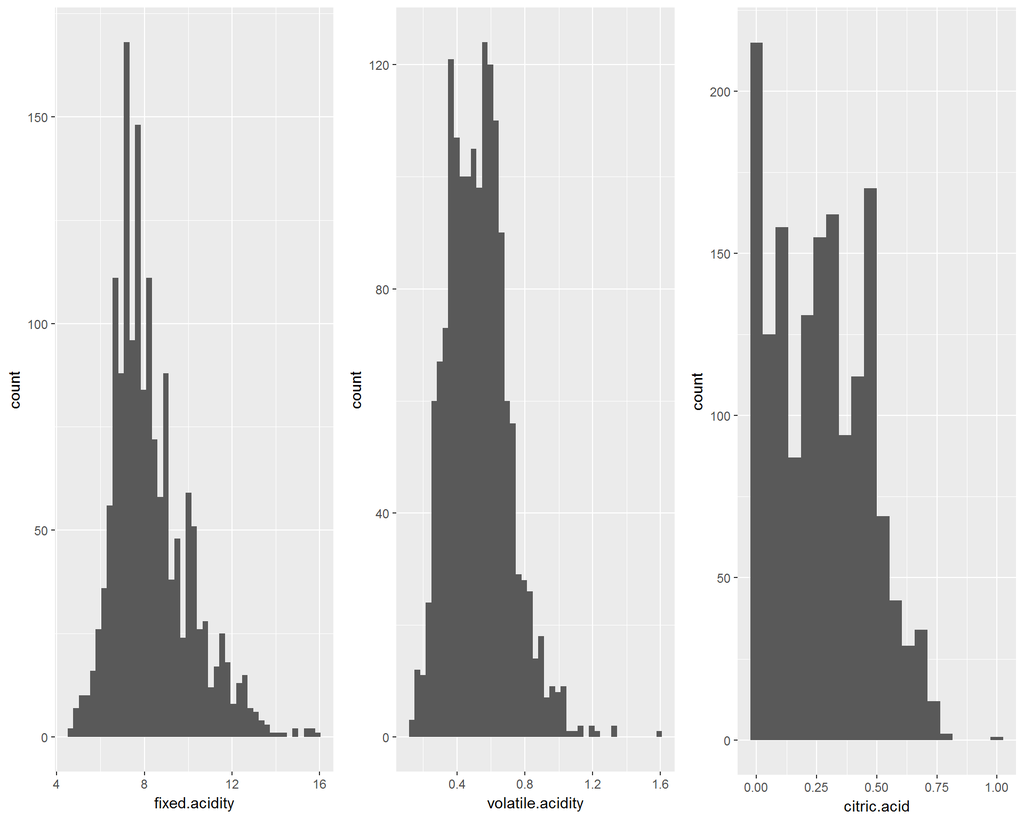

```
##    Min. 1st Qu.  Median    Mean 3rd Qu.    Max.
##    4.60    7.10    7.90    8.32    9.20   15.90
```

```
##    Min. 1st Qu.  Median    Mean 3rd Qu.    Max.
##  0.1200  0.3900  0.5200  0.5278  0.6400  1.5800
```

```
##    Min. 1st Qu.  Median    Mean 3rd Qu.    Max.
##   0.000   0.090   0.260   0.271   0.420   1.000
```

Fixed.acidity and volatile.acidity have roughly normal distributions. The amount of volatile.acidity is very low with a mean of 0.53 g/dm^3. The citric acid is also found in small quantities in red wines with an average of 0.27 g/dm^3.

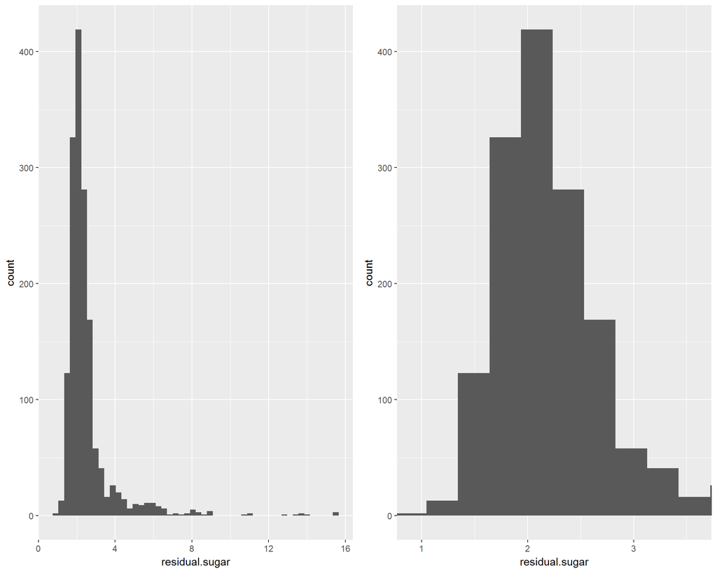

```
##    Min. 1st Qu.  Median    Mean 3rd Qu.    Max.
##   0.900   1.900   2.200   2.539   2.600  15.500
```

```
## [1] 2
```

The amount of residual sugar is low with a mean of 2.5 g/litre. The distribution if highly skewed to the right. To see the proper distribution of the amount of residual sugar in wines, we put a limit on the x-axis to show maximum amount at 90% quartile (Please refer to above the right-hand side plot). According to dataset description, wine with more than 45 g/litre of residual sugar is considered a sweet wine. However, in the given dataset the maximum residual sugar is 15.5 g/litre. The description also notes that wine less than 1 g/litre residual sugar is rare. In the given dataset there are two wines with less than 1 g/litre residual sugar. I personally like sweet wines. I am curious if it has any relationship with quality of wine.

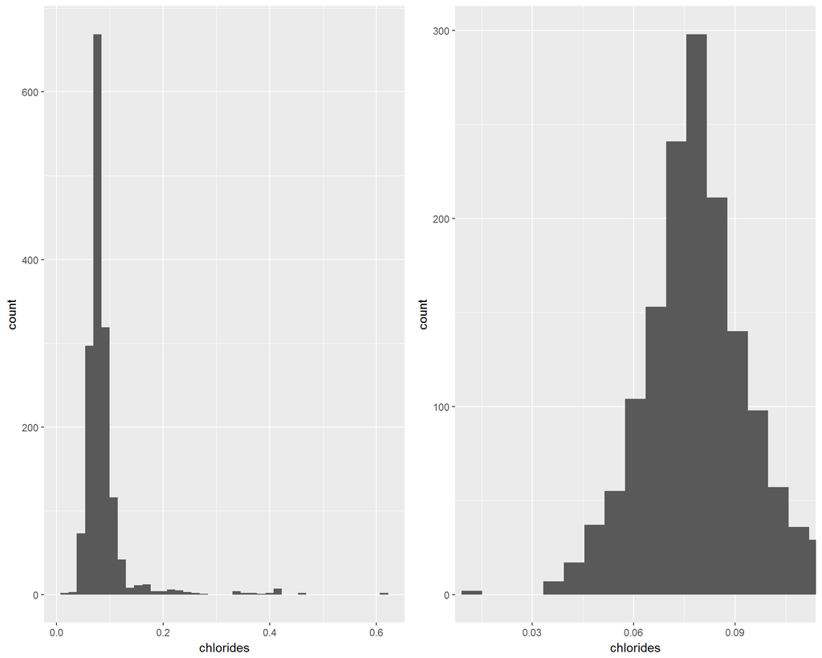

```
##    Min. 1st Qu.  Median    Mean 3rd Qu.    Max.
## 0.01200 0.07000 0.07900 0.08747 0.09000 0.61100
```

The attribute chloride represents the amount of salt in wine. Most of the wines have a small amount of salt less than 0.2. To see the proper distribution of the amount of salt in most of the wines, we put a limit on the x-axis to show maximum salt amount at 95% quartile (Please refer to above the right hand side plot).

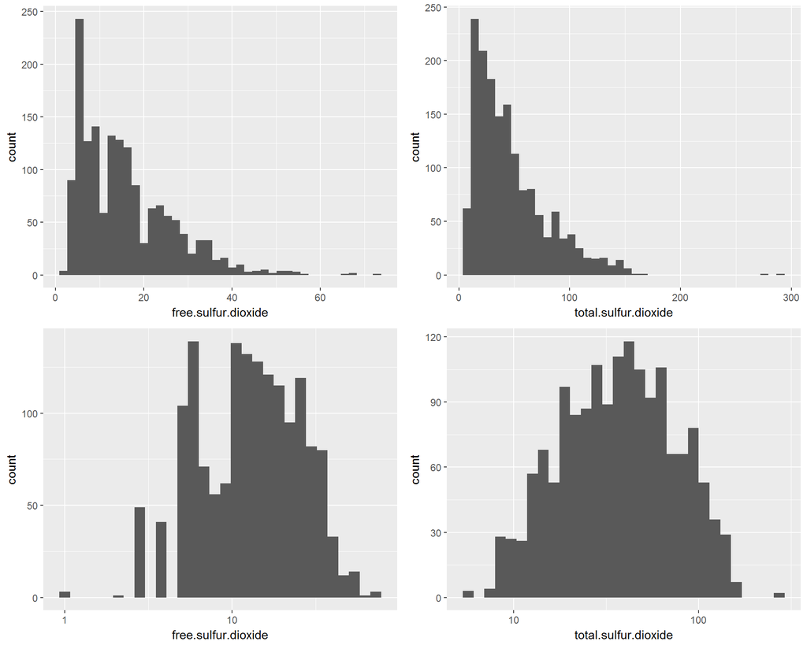

The above plot shows the amount of free and total sulphur dioxide in wines. From the top row of the above plot, we see that distribution of amount is skewed with long tails. The bottom row of the plot shows when the amount is log transformed.

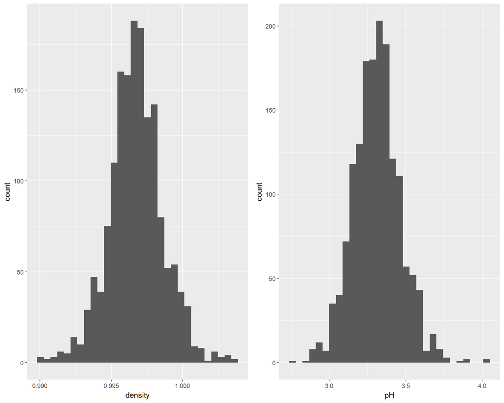

The above plot shows the distribution of density and pH level of wines. The density for most of the wines is little less than one, which is the density of water. Also, most of the wines are in the range of 3 and 3.7, which is acidic.

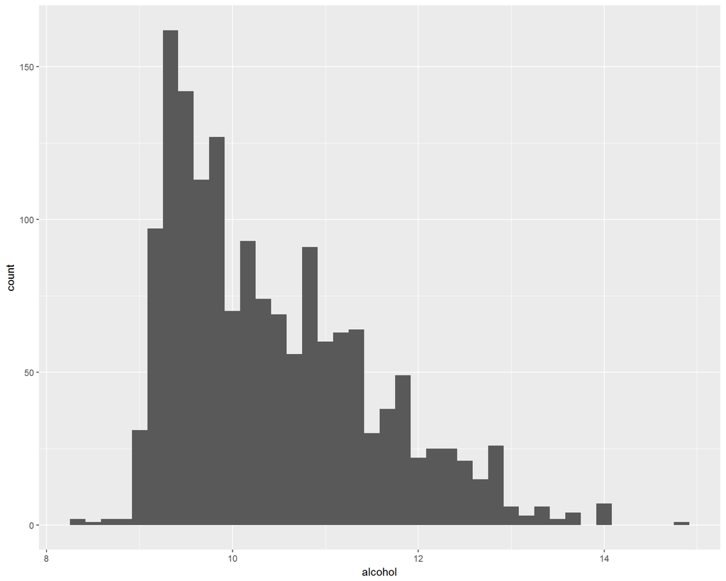

```
##    Min. 1st Qu.  Median    Mean 3rd Qu.    Max.
##    8.40    9.50   10.20   10.42   11.10   14.90
```

The mean percent of alcohol content is 10.42%. 75% of wines have alcohol content less than 11.1%. It would be interesting to see if Alcohol content has any correlation with the quality of wine.

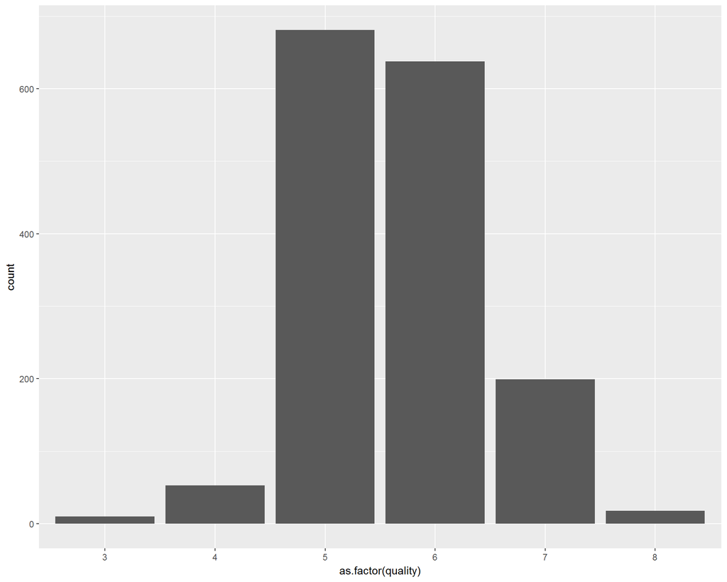

```
##    Min. 1st Qu.  Median    Mean 3rd Qu.    Max.
##   3.000   5.000   6.000   5.636   6.000   8.000
```

```
##
##   3   4   5   6   7   8
##  10  53 681 638 199  18
```

Most of the wines have a quality rating of 5 and 6. The highest possible rating is ten, but none of the wines in the dataset has got full rating. 18 of the wines have got a quality rating of 8 (maximum rating in the dataset). It would be interesting to see what all objective measures relate with these ratings.

# Univariate Analysis

### What is the structure of your dataset?

There are 1599 wines in the dataset with 12 attributes. 11 of the attributes are objective measures, and one attribute is subjective quality rating.

### What is/are the main feature(s) of interest in your dataset?

I think the main features are volatile acidity, residual sugar, and alcohol content. I suspect these features will have either positive or negative correlation with quality ratings.

### What other features in the dataset do you think will help support your investigation into your feature(s) of interest?

I think pH and total sulphur dioxide might also influence the subjective quality ratings.

### Did you create any new variables from existing variables in the dataset?

I did not make any new variable. As all the variables were on the continuous scale and most of them were normally distributed. If any of the variables had uniform distribution, I would have made that variable into a categorical variable using the cut function. However, for the given dataset I did not feel any need of it.

### Of the features you investigated, were there any unusual distributions? Did you perform any operations on the data to tidy, adjust, or change the form of the data? If so, why did you do this?

The dataset included a column ‘X’ which represented row number. I removed that column from the dataset as that was not relevant or useful for the analysis.

I found the distribution of Chlorides as unusual. It has a normal distribution, but with a very long tail. To make the plot look tidy, I limited x coordinate to have a max value of 95% quartile of chloride quantity. Similarly, the distribution of free sulphur dioxide and total sulphur dioxide seemed skewed with long tails. I transformed x using log10 transformation. The resulting plot looks more normal now.

# Bivariate Plots Section

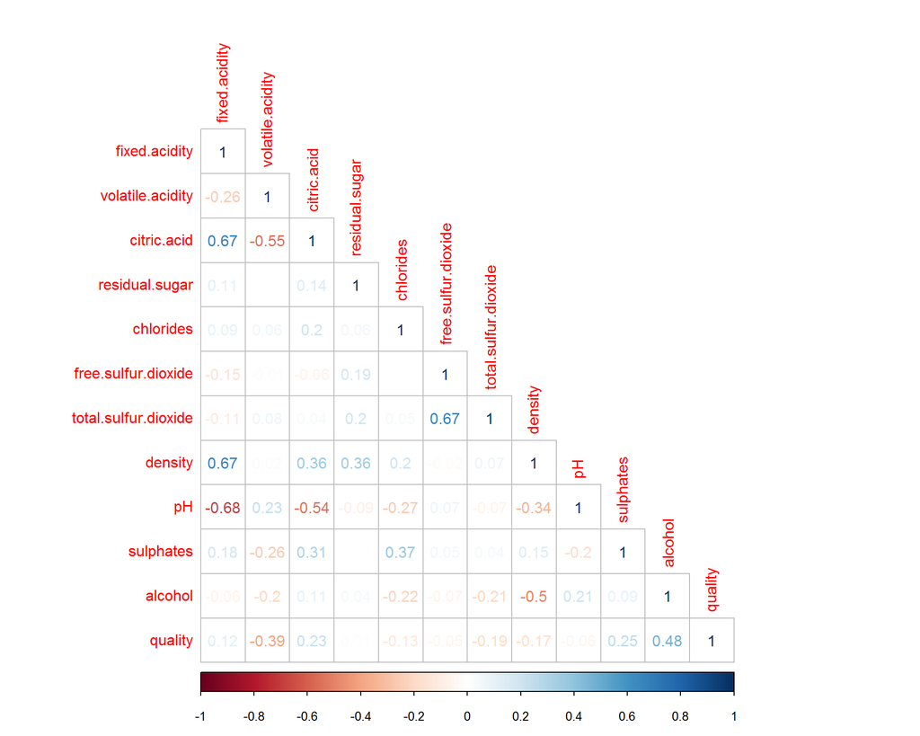

From the above plots, we do not see that Quality has strong correlations with any of the other attributes. The quality rating has a best positive correlation of 0.48 with alcohol content and best negative correlation of -0.39 with volatile.acidity. Let’s take a close look at these relationships.

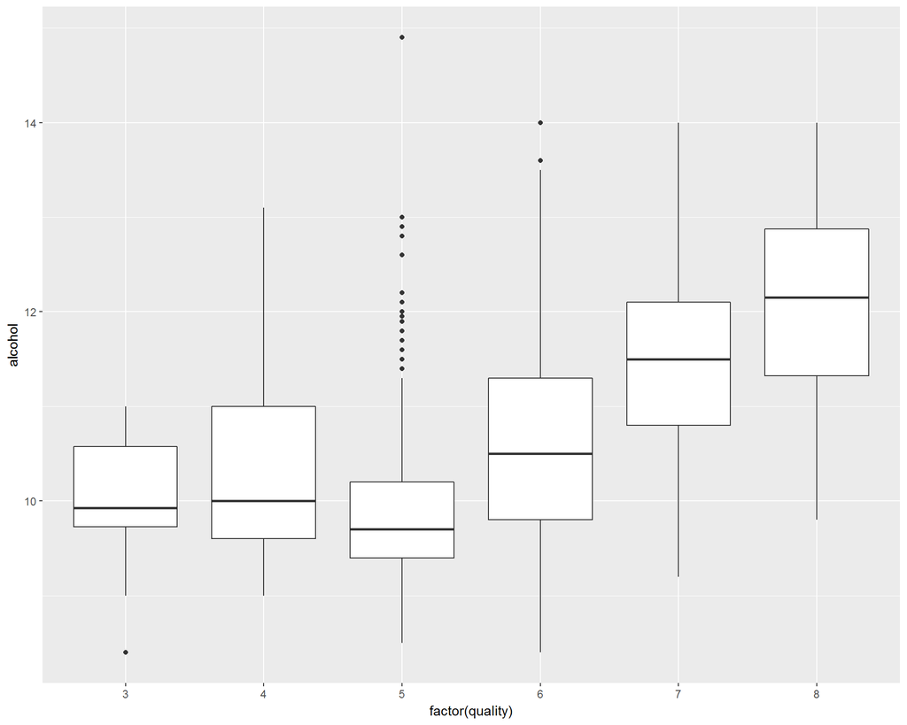

The above plot shows boxplot of alcohol content at each quality rating. It seems that higher rated wines have high alcohol content.

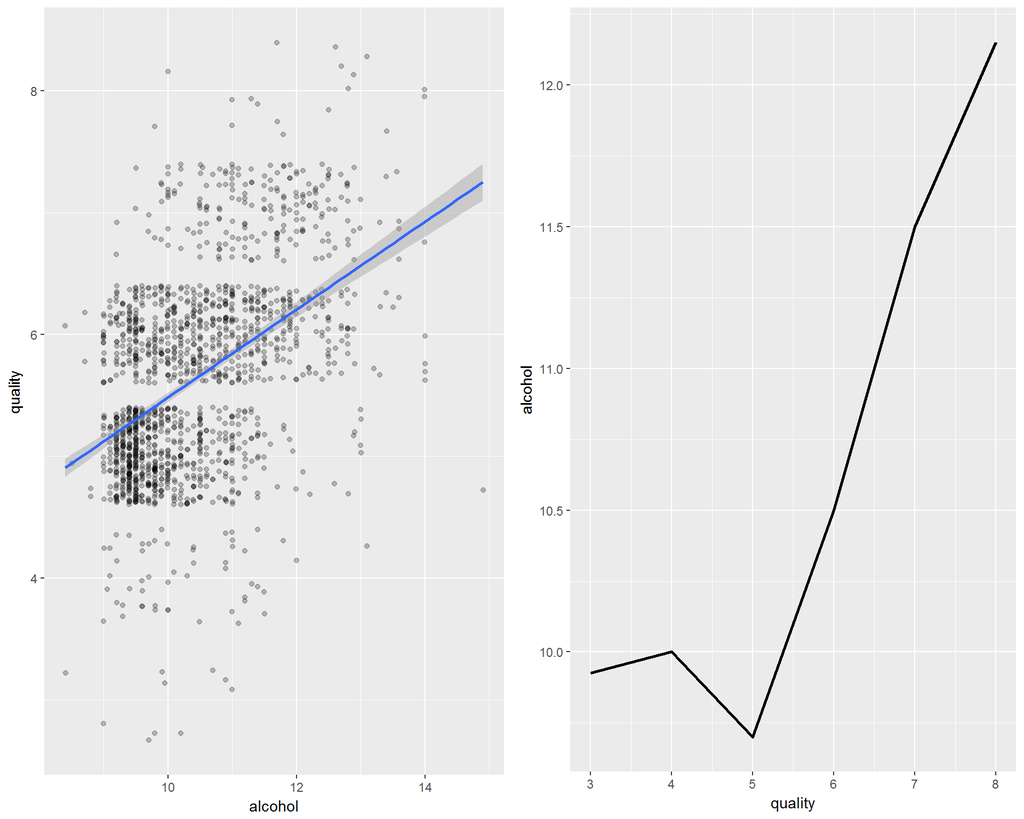

And indeed the scatter plot shows a weak positive correlation between the quality and the alcohol content.

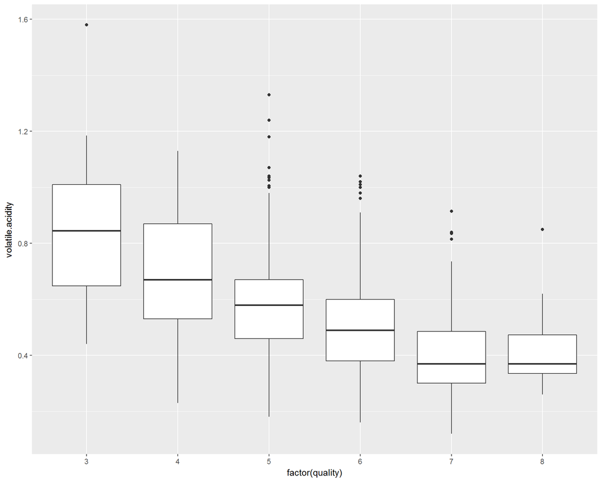

The above boxplot shows the amount of volatile acidity at each quality rating. It seems that higher rated wines have low volatile acidity.

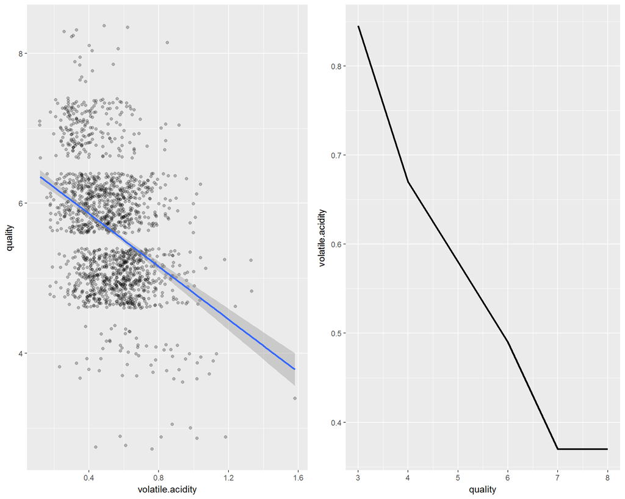

This plot indicates that as the content of volatile acidity increases the quality rating decreases and hence has a negative correlation.

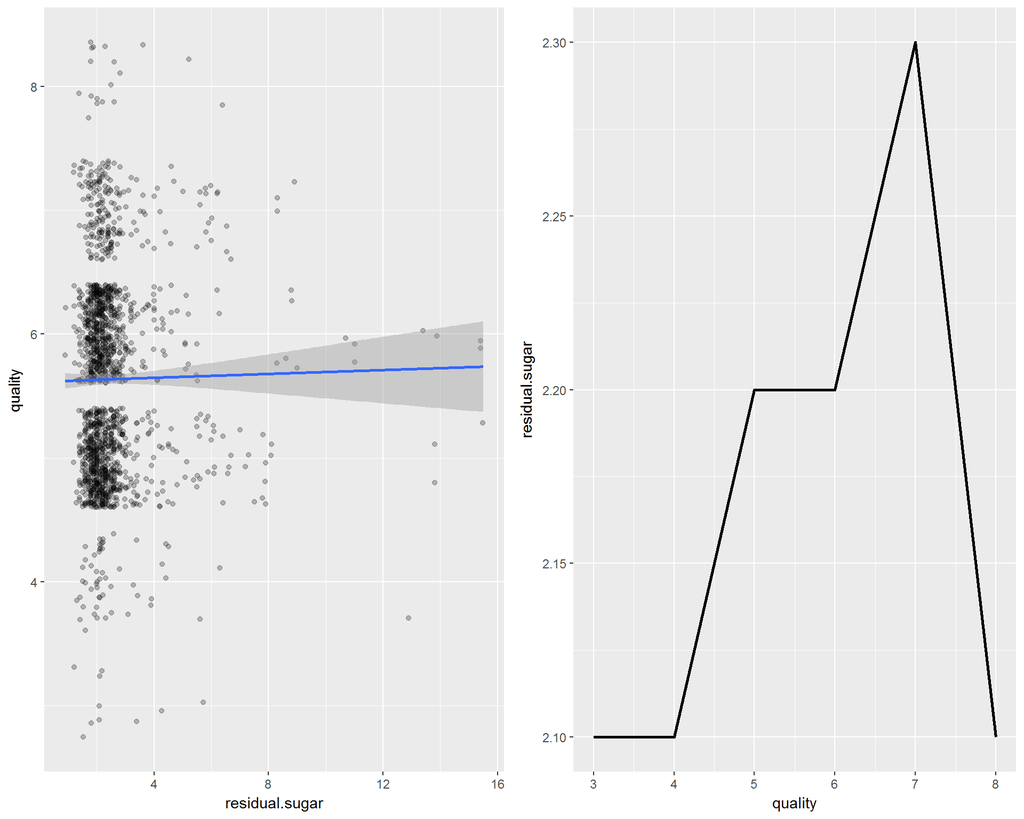

```
##
##  Pearson's product-moment correlation
##
## data:  wqr$residual.sugar and wqr$quality
## t = 0.5488, df = 1597, p-value = 0.5832
## alternative hypothesis: true correlation is not equal to 0
## 95 percent confidence interval:
##  -0.03531327  0.06271056
## sample estimates:
##        cor
## 0.01373164
```

I suspected that the residual sugar would be a good predictor of quality. However, the plot suggests that there is no relationship between the amount of residual sugar and the quality of wine.

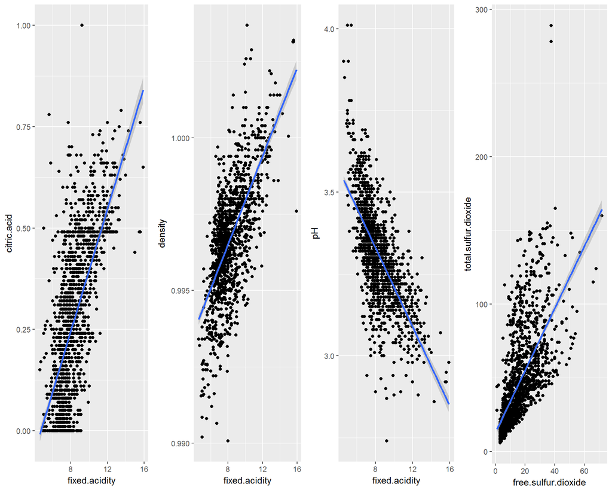

The above plot shows some of the strong relationships between other attributes.

# Bivariate Analysis

### Talk about some of the relationships you observed in this part of the investigation. How did the feature(s) of interest vary with other features in the dataset?

I suspected that volatile acidity, residual sugar, and alcohol content would be a strong predictor of quality. However, looking at the scatter plot, we do not see any strong relationships. The best positive correlation is of 0.48 between quality rating and alcohol content. In the description of the attributes, it is mentioned that high levels of volatile acidity could lead to an unpleasant taste. Indeed the scatter plot revealed a negative correlation of -0.39. The amount of residual sugar did not show any relationship with the quality rating. I might be biased by my personal preferences of sweet red wines, may be wine experts do not like sweet wines. Also according to the dataset description, wines with residual sugar above 45 grams/liter are considered sweet, but none of the wines in the dataset has this much amount of residual sugar.

### Did you observe any interesting relationships between the other features (not the main feature(s) of interest)?

Yes, I found other strong correlations between fixed acidity and citric acid, fixed acidity and density, fixed acidity and pH, and free sulphur dioxide and total sulphur dioxide. Most of these make sense, but I did not understand why acidity is correlated with density.

### What was the strongest relationship you found?

The strongest relationship (correlation=-0.68) was between free acidity and pH value. This was expected because the pH value is used to measure the acidity of any aqueous solution.

# Multivariate Plots Section

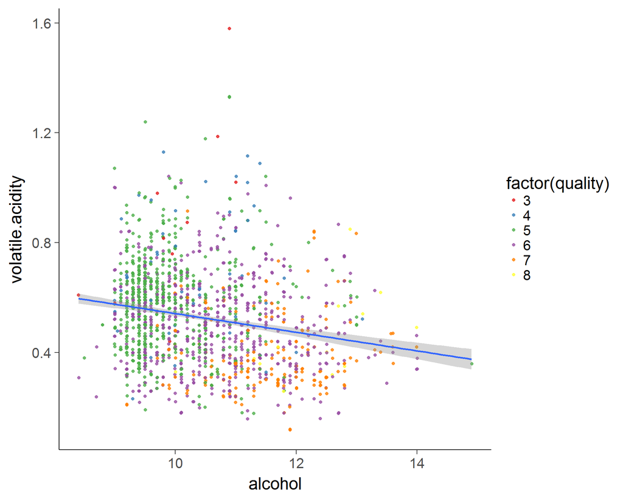

This plot clearly shows that wines with low alcohol content and high volatile acidity are rated low (shown in green points).

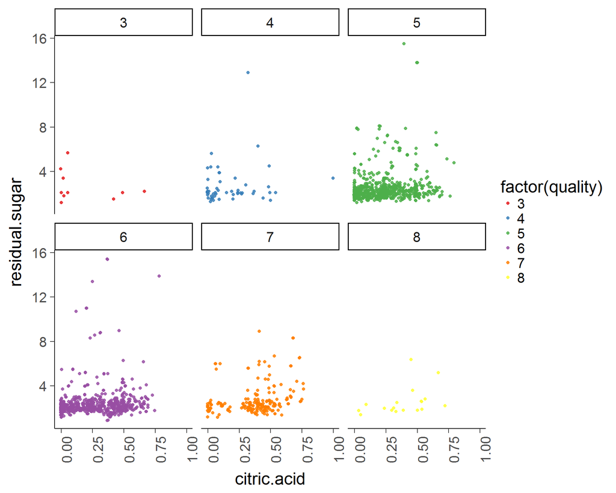

In this plot also we do not see any strong combined effect of residual.sugar and citric.acid in the quality ratings.

```
##
## Calls:
## m1: lm(formula = quality ~ alcohol, data = wqr)
## m2: lm(formula = quality ~ alcohol + volatile.acidity, data = wqr)
## m3: lm(formula = quality ~ alcohol + volatile.acidity + sulphates,
##     data = wqr)
## m4: lm(formula = quality ~ alcohol + volatile.acidity + sulphates +
##     citric.acid, data = wqr)
## m5: lm(formula = quality ~ alcohol + volatile.acidity + sulphates +
##     citric.acid + total.sulfur.dioxide, data = wqr)
##
## ===============================================================================
##                            m1         m2         m3         m4         m5
## -------------------------------------------------------------------------------
##   (Intercept)            1.875***   3.095***   2.611***   2.646***   2.843***
##                         (0.175)    (0.184)    (0.196)    (0.201)    (0.205)
##   alcohol                0.361***   0.314***   0.309***   0.309***   0.295***
##                         (0.017)    (0.016)    (0.016)    (0.016)    (0.016)
##   volatile.acidity                 -1.384***  -1.221***  -1.265***  -1.222***
##                                    (0.095)    (0.097)    (0.113)    (0.112)
##   sulphates                                    0.679***   0.696***   0.721***
##                                               (0.101)    (0.103)    (0.103)
##   citric.acid                                            -0.079     -0.043
##                                                          (0.104)    (0.104)
##   total.sulfur.dioxide                                              -0.002***
##                                                                     (0.001)
## -------------------------------------------------------------------------------
##   R-squared                  0.2        0.3        0.3        0.3        0.3
##   adj. R-squared             0.2        0.3        0.3        0.3        0.3
##   sigma                      0.7        0.7        0.7        0.7        0.7
##   F                        468.3      370.4      268.9      201.8      167.0
##   p                          0.0        0.0        0.0        0.0        0.0
##   Log-likelihood         -1721.1    -1621.8    -1599.4    -1599.1    -1589.7
##   Deviance                 805.9      711.8      692.1      691.9      683.8
##   AIC                     3448.1     3251.6     3208.8     3210.2     3193.5
##   BIC                     3464.2     3273.1     3235.7     3242.4     3231.1
##   N                       1599       1599       1599       1599       1599
## ===============================================================================
```

```
##
## Call:
## lm(formula = quality ~ alcohol + volatile.acidity + sulphates +
##     citric.acid + total.sulfur.dioxide, data = wqr)
##
## Residuals:
##      Min       1Q   Median       3Q      Max
## -2.72463 -0.38380 -0.06689  0.44606  2.14550
##
## Coefficients:
##                        Estimate Std. Error t value Pr(>|t|)
## (Intercept)           2.8431068  0.2050732  13.864  < 2e-16 ***
## alcohol               0.2953419  0.0160375  18.416  < 2e-16 ***
## volatile.acidity     -1.2223102  0.1124774 -10.867  < 2e-16 ***
## sulphates             0.7207881  0.1027039   7.018 3.32e-12 ***
## citric.acid          -0.0427246  0.1035810  -0.412     0.68
## total.sulfur.dioxide -0.0022182  0.0005126  -4.327 1.60e-05 ***
## ---
## Signif. codes:  0 '***' 0.001 '**' 0.01 '*' 0.05 '.' 0.1 ' ' 1
##
## Residual standard error: 0.6552 on 1593 degrees of freedom
## Multiple R-squared:  0.3439, Adjusted R-squared:  0.3418
## F-statistic:   167 on 5 and 1593 DF,  p-value: < 2.2e-16
```

The attributes included in the linear model (alcohol, volatile.acidity, sulphates, citric.acid, total.sulfur.dioxide) can account for only 34% of the variance in the quality ratings.

# Multivariate Analysis

### Talk about some of the relationships you observed in this part of the investigation. Were there features that strengthened each other in terms of looking at your feature(s) of interest?

We did not find any pairs of attributes which together were a good predictor of quality. In the plot above (residual.sugar vs. Citric.acid), we see that wines with same quality ratings are all over the plot regions, indicating no strong relationships. Except for wines with a quality rating of 3 have a small amount of citric acid, but there also exists many highly rated wines (6 and above) which has low citric.acid.

### Were there any interesting or surprising interactions between features?

Even though individual attributes do not have strong relationships with quality, I expected that together they would be a good predictor of the quality. However, none of the multivariate plots showed any improvement with combinations of attributes.

### OPTIONAL: Did you create any models with your dataset? Discuss the strengths and limitations of your model.

Yes, I made five linear models to predict the quality ratings. However, the the best model could only predict is 34% of variance. I think, either more objective measures are required, or there is a complex non-linear relationship in high-dimensions between quality and the objective attributes which are not apparent in scatter plots.

# Final Plots and Summary

### Plot One

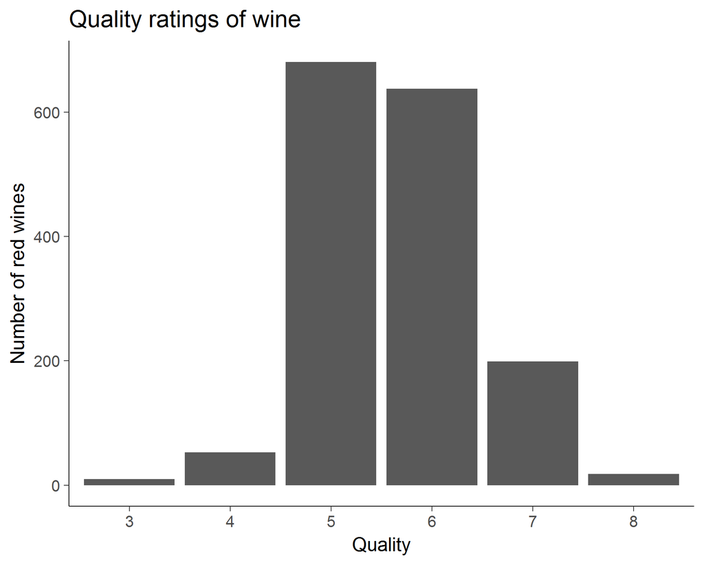

### Description One

The distribution of quality ratings of red wines. This distribution is fairly normal with most of the wines rated 5 and 6. The possible lowest rating was 0, and the highest rating was 10. However, none of the wines in the dataset achieved a rating of 9 and above.

### Plot Two

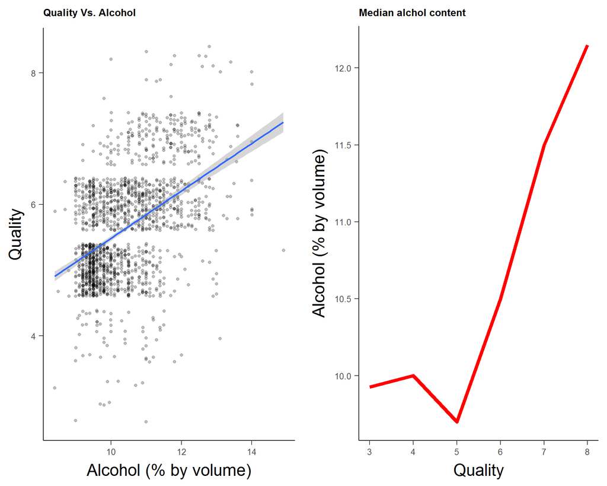

### Description Two

The left side plot above is scattered plot of the quality rating and the alcohol content of the wines. We see there is a weak positive correlation between the two attributes. The weak linear trend is shown using the blue line in the plot. The right side plot above shows the median alcohol content in wines at each quality rating. Again this plot shows there is some relationship between the quality and the alcohol content.

### Plot Three

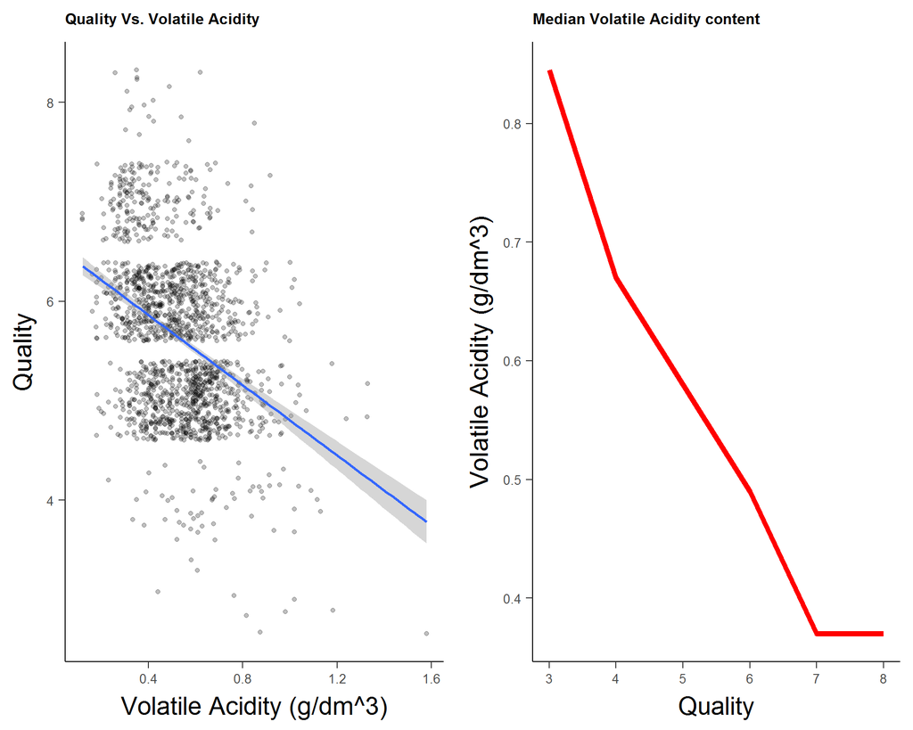

### Description Three

The left side plot above is scattered plot of the quality rating and the volatile acidity of the wines. We see there is a weak negative correlation between the two attributes. The weak linear trend is shown using the blue line in the plot. The right side plot above shows the median volatile acidity amount in wines at each quality rating. Again this plot shows there is some relationship between the quality and the volatile acidity.

# Reflection

The wine quality rating dataset has data for 1599 red wines. The dataset provides 11 objective measures for each wine and one subjective rating. I explored each of the 11 objective measures and analysed the relationships of these objective measures with the subjective ratings. Finally, based on the exploratory analysis I created five linear models to predict the quality of a wine based on the objective measures.

Based on the description of the objective measures provided, I suspected that volatile acidity, residual sugar, alcohol content, pH and total sulphur dioxide would be strong predictors of subjective quality ratings. However, the scatterplots of the objective measures with the quality ratings revealed no strong relationships. The quality rating had the best correlation of 0.48 with alcohol content and the second best correlation of -0.39 with volatile acidity. Next, I hoped that together these objective measures might be a good predictor of quality. Hence I created five linear models with different combinations of the objective measure. The best model (m5) with five objective measures could only account for 34% of the variance.

# Limitations and future improvements

I suspect that the linear model is not able to explain much of the variance because either the dataset is missing some other important objective measures or there are some complex non-linear relationships between the given objective measures and the quality ratings which is not visible in the scatterplots. Scatterplots can only show second order relationships, but I suspect that the given dataset has higher order relationships. These higher order relationships can be explored using much more sophisticated machine learning tools such as SVM, or neural networks.

Also, most of the wines in the dataset have average ratings between 4 and 7. The data set has no inferior wines with a rating less than 3 and no excellent wines with a rating greater than 8. I think if the data were provided with balanced classes of wines then the linear model would have been much better.